# Reproducible Research-Assessment 1

Lin weifu

July 17, 2015

## 1.Loading and preprocessing the data

```r
setwd('./data')
mydata <- read.csv("./activity.csv",header = TRUE, stringsAsFactors=FALSE)
mydata$date<- as.Date(mydata$date, "%Y-%m-%d")
time <- formatC(mydata$interval/100, 2, format = "f")
time <- strptime(time, "%H.%M")
mydata$time <- format(time, format = "%H:%M:%S")
mydata$time <- as.POSIXct(mydata$time, format = "%H:%M:%S")
```

## 2.What is mean total number of steps taken per day?

The table of total number of steps taken per day

```r
agtable<-aggregate(mydata$steps, by=list(mydata$date), sum, na.rm = TRUE)
names(agtable) <- c("date", "steps")
```

The Histogram of the total number of steps taken each day

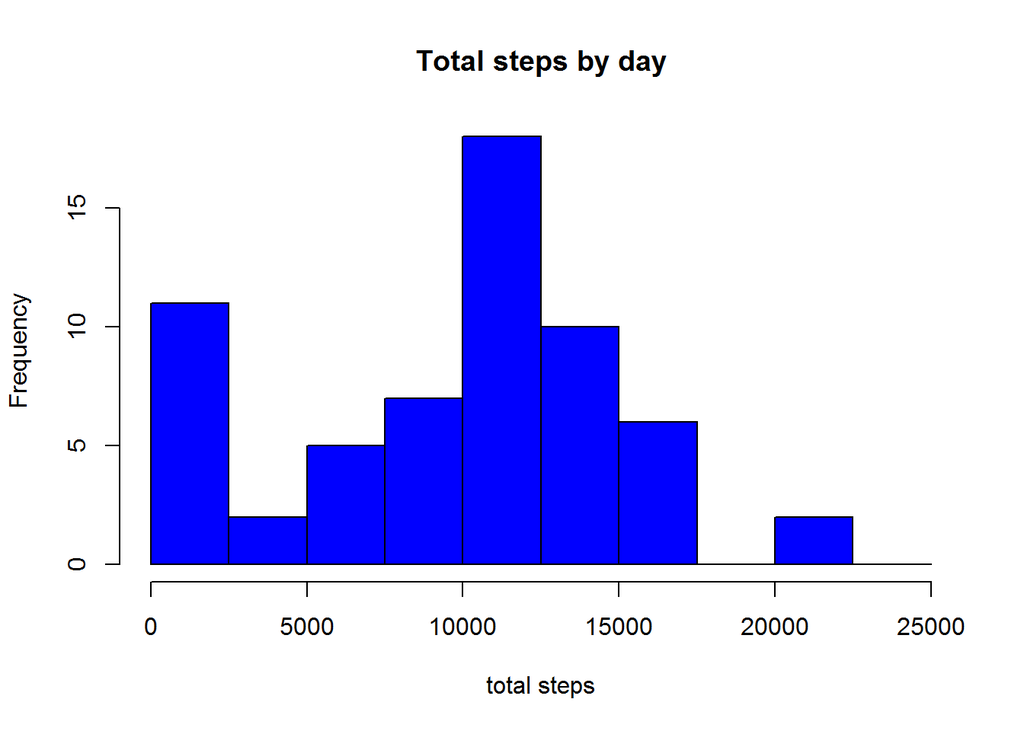

```r
hist(agtable$steps,col="blue",main = "Total steps by day",xlab = "total steps",
     breaks=seq(from=0, to=25000, by=2500))
```

The mean and median of the total number of steps taken per day

```r
mean(agtable$steps)
```

```
## [1] 9354.23
```

```r
median(agtable$steps)
```

```
## [1] 10395
```

## 3.What is the average daily activity pattern?

Time series plot of the 5-minute interva

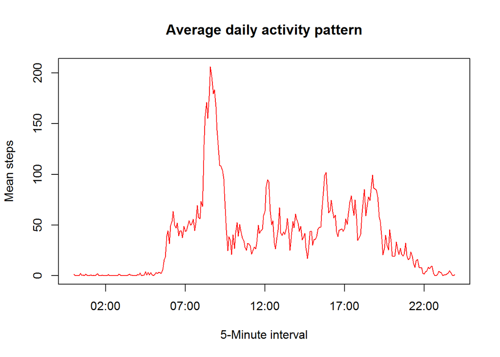

```r
agtable_mean<-aggregate(steps~time,mydata,mean,na.rm=TRUE)
plot(agtable_mean,type="l",col="red" ,main="Average daily activity pattern"
     ,xlab = " 5-Minute interval ",ylab="Mean steps")
```

Which 5-minute interval, on average across all the days in the dataset, contains the maximum number of steps?

```r
agtable_mean$time <- format(agtable_mean$time, format = "%H:%M:%S")
max_steps_time <- which.max(agtable_mean$steps)
print(agtable_mean[max_steps_time,])
```

```
##         time    steps
## 104 08:35:00 206.1698
```

## 4.Imputing missing values

Calculate and report the total number of missing values

```r
sum(is.na(mydata$steps))
```

```
## [1] 2304
```

Create a new dataset with the missing data replaced by mean and filled in.

```r
# Find the NA positions
na_pos <- which(is.na(mydata$steps))

# Create a vector of means
mean_vec <- rep(mean(mydata$steps, na.rm=TRUE), times=length(na_pos))

# Replace the NAs by the means
mydata$newsteps<-mydata$steps
mydata[na_pos, "newsteps"] <- mean_vec

# Clear the workspace
rm(mean_vec, na_pos)
```

[figure not shown]

The mean and median are computed like

```r
mean(agtable2$newsteps)
```

```
## [1] 10766.19
```

```r
median(agtable2$newsteps)
```

```
## [1] 10766.19
```

These values differ greatly from the estimates from the first part of the assignment. The impact of imputing the missing values is to have more data, hence to obtain a bigger mean and median value.

## 5.Are there differences in activity patterns between weekdays and weekends?

Create a new factor variable in the dataset with two levels – “weekday” and “weekend”

```r
# show the date as English date

Sys.setlocale(,"C")
```

```
## [1] "C"
```

```r
# Create a new weekday dataframe
mydata$weekday<-weekdays(mydata$date)
mydata$weekday[mydata$weekday %in% c("Saturday","Sunday")]<- "weekend"
mydata$weekday[mydata$weekday != "weekend"]<- "weekday"

# Compute the average number of steps taken, averaged across all daytype variable
mean_data <- aggregate(mydata$steps,
                       by=list(mydata$weekday,mydata$interval), mean,na.rm=TRUE)
names(mean_data) <- c("weekday", "interval", "mean")
```

The time series plot take the following form:

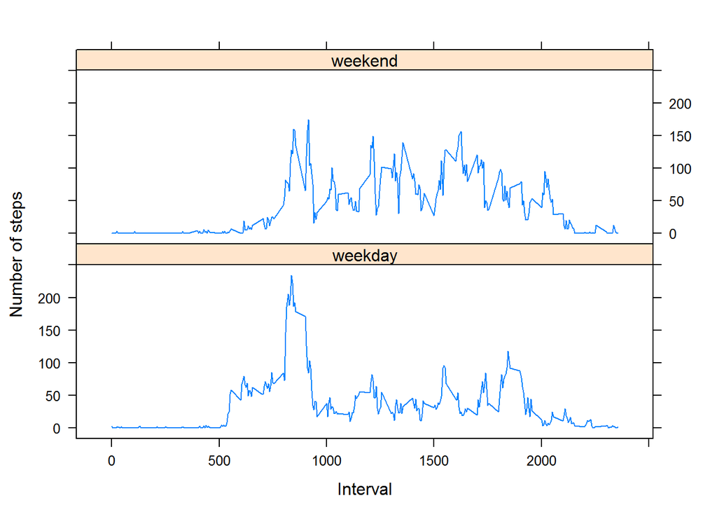

```r
# Load the lattice graphical library
library(lattice)

# Compute the time serie plot
xyplot(mean ~ interval | weekday, mean_data,
       type="l",
       lwd=1,
       xlab="Interval",
       ylab="Number of steps",
       layout=c(1,2))
```